# Interest Rates and R&D - Proof of Concept

## e. Do the same regression, but this time using the data for all the runners. Plot the two regressions as lines in the same plot and compare them. Under what conditions will they become more similar?

```r
p_lin <- lm(data = d, formula = time_seconds ~ age)

summary(p_lin)
```

```
Call:
lm(formula = time_seconds ~ age, data = d)

Residuals:
    Min      1Q  Median      3Q     Max
-8372.1 -2536.9  -454.4  2027.1 25677.4

Coefficients:
            Estimate Std. Error t value Pr(>|t|)
(Intercept) 13703.37      55.25  248.03   <2e-16 ***
age            65.26       1.33   49.08   <2e-16 ***
---
Signif. codes:  0 '***' 0.001 '**' 0.01 '*' 0.05 '.' 0.1 ' ' 1

Residual standard error: 3631 on 55460 degrees of freedom
Multiple R-squared:  0.04162,   Adjusted R-squared:  0.0416
F-statistic:  2408 on 1 and 55460 DF,  p-value: < 2.2e-16
```

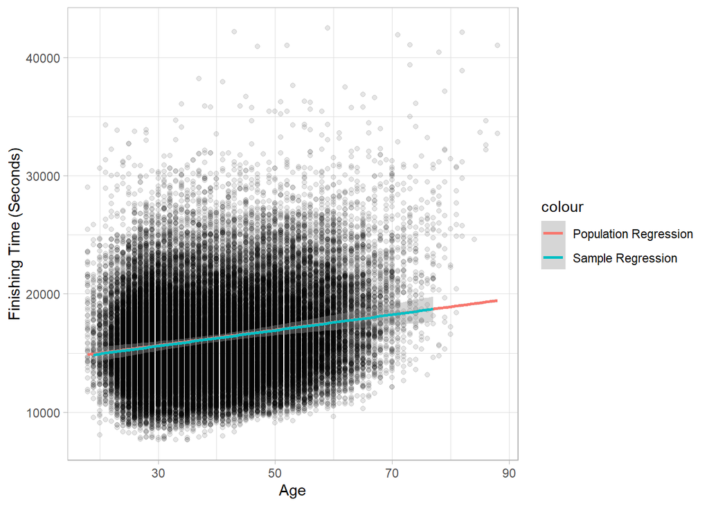

```r
ggplot() +
  geom_point(data = d,
       aes(x = age,
           y = time_seconds),
       alpha = .1) +
  labs(x = "Age",
       y = "Finishing Time (Seconds)") +
  geom_smooth(method = "lm",
              SE = FALSE,
              aes(col = 'Population Regression',
                  x = age,
                  y = time_seconds),
              data = d) +
  geom_smooth(method = "lm",
              SE = FALSE,
              aes(col = 'Sample Regression',
                  x = age,
                  y = time_seconds),
              data = s)
```

The lines will generally be more similar given a greater sample size.

## f. Take repeated samples of size 500 (at least 1000 samples). For each sample, run the same regression and extract the coefficient for age. Plot the distribution of coefficients and compare it to the age coefficient in the whole sample, what do you observe?

```r
draw_sample <- function(d = d, n = 500) {
  samp <- slice_sample(.data = d,
                       n = n,
                       replace = FALSE)
  samp_lin <- lm(data = samp, formula = time_seconds ~ age)
  samp_lin$coefficients[2]
}

samples <- tibble(sample_id = 1:10000) |>
  rowwise() |>
  mutate(age_coefficient = draw_sample(d = d, n = 500))
```

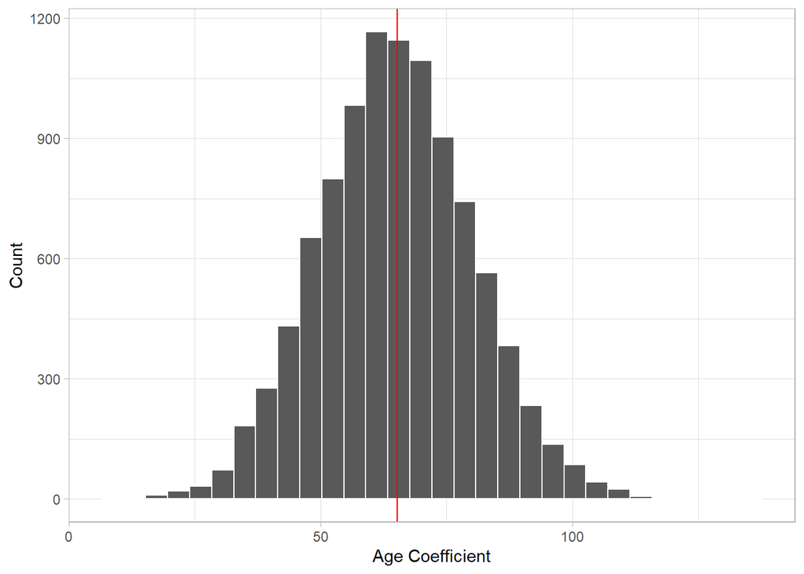

```r
ggplot(data = samples,
       aes(x = age_coefficient)) +
  geom_histogram(color = "white") +
  labs(x = "Age Coefficient",
       y = "Count") +
  geom_vline(xintercept = p_lin$coefficients[2],
             color = "red")
```

The age coefficient for the population regression 65.26 (marked with the red line) is roughly the same as the mean age coefficient for the regressions performed on the samples 64.95. The age coefficients appear normally distributed around that mean.